# Titanic Passenger Classification

Shaikh Ibrahim Noman

# Titanic data

## Loading and cleaning the data

```r
# Loading in the data
titanic <- carData::TitanicSurvival

# Removing the row names because we don't need them
rownames(titanic) <- NULL

# Removing the N/A values
titanic <- na.omit(titanic)

# Create a new categorical variable for Age_Category
titanic$Age_Category <- NA

# Define the age categories
age_categories <- c("Child", "Adult", "Elderly")

# Assign age categories based on age values
titanic$Age_Category[titanic$age < 18] <- age_categories[1]  # Child
titanic$Age_Category[titanic$age >= 18 & titanic$age < 65] <- age_categories[2]  # Adult
titanic$Age_Category[titanic$age >= 65] <- age_categories[3]  # Elderly

# Removing the age variable because we have the category variable
titanic <- titanic[,-3]
```

## Descriptive Statistics

```r
stats.titanic <- describe(titanic)
head(stats.titanic)
```

|  | vars | n | mean | sd | median | trimmed | mad | min | max | range | skew | kurtosis | se |
| --- | --- | --- | --- | --- | --- | --- | --- | --- | --- | --- | --- | --- | --- |
| survived* | 1 | 1046 | 1.408222 | 0.4917397 | 1 | 1.385442 | 0.0000 | 1 | 2 | 1 | 0.3729227 | -1.862707 | 0.01520441 |
| sex* | 2 | 1046 | 1.629063 | 0.4832867 | 2 | 1.661098 | 0.0000 | 1 | 2 | 1 | -0.5335951 | -1.716915 | 0.01494304 |
| passengerClass* | 3 | 1046 | 2.207457 | 0.8414966 | 2 | 2.258950 | 1.4826 | 1 | 3 | 2 | -0.4057233 | -1.471242 | 0.02601876 |
| Age_Category* | 4 | 1046 | 1.172084 | 0.4092529 | 1 | 1.075179 | 0.0000 | 1 | 3 | 2 | 2.2638392 | 4.438298 | 0.01265394 |

## Visualizations

### Distribution of Class and Sex

The plot below shows the relationship between the genders and which class they belong to. From this plot we can conclude that the majority of the passengers were male.

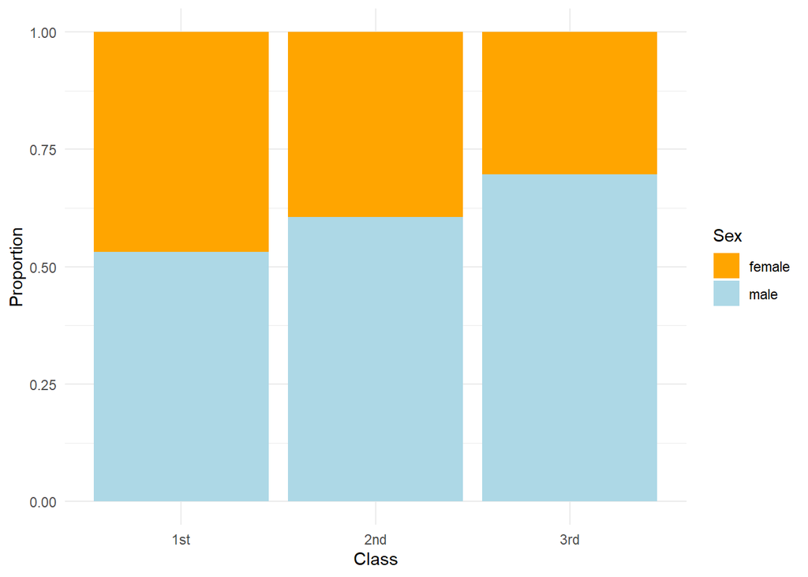

```r
ggplot(titanic, aes(x = passengerClass, fill = sex)) +
  geom_bar(position = "fill") +
  labs(x = "Class", y = "Proportion", fill = "Sex") +
  scale_fill_manual(values = c("female" = "orange", "male" = "lightblue")) +
  theme_minimal()
```

## Survived or Not?

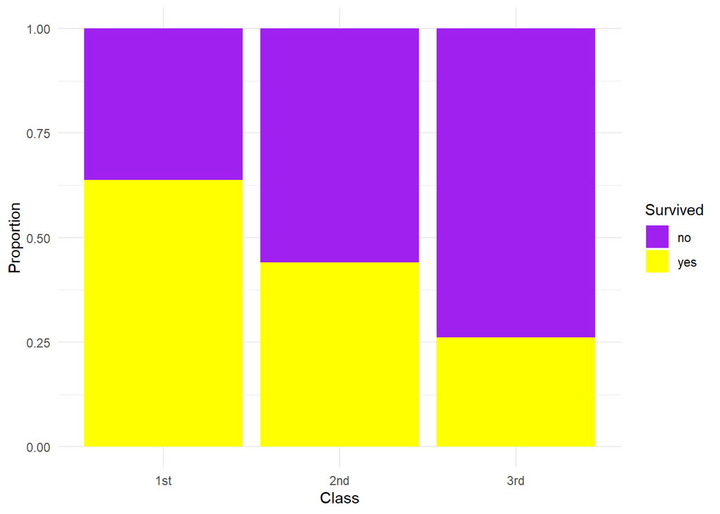

```r
ggplot(titanic, aes(x = passengerClass, fill = survived)) +
  geom_bar(position = "fill") +
  labs(x = "Class", y = "Proportion", fill = "Survived") +
  scale_fill_manual(values = c("yes" = "yellow", "no" = "purple")) +
  theme_minimal()
```

# Building a model

## Splitting our data

```r
# Creating a train and a test set
set.seed(7)
train_index <- createDataPartition(titanic$survived, p = 0.8, list = FALSE)
train <- titanic[train_index,]
test <- titanic[-train_index,]
```

### Train vs. Test

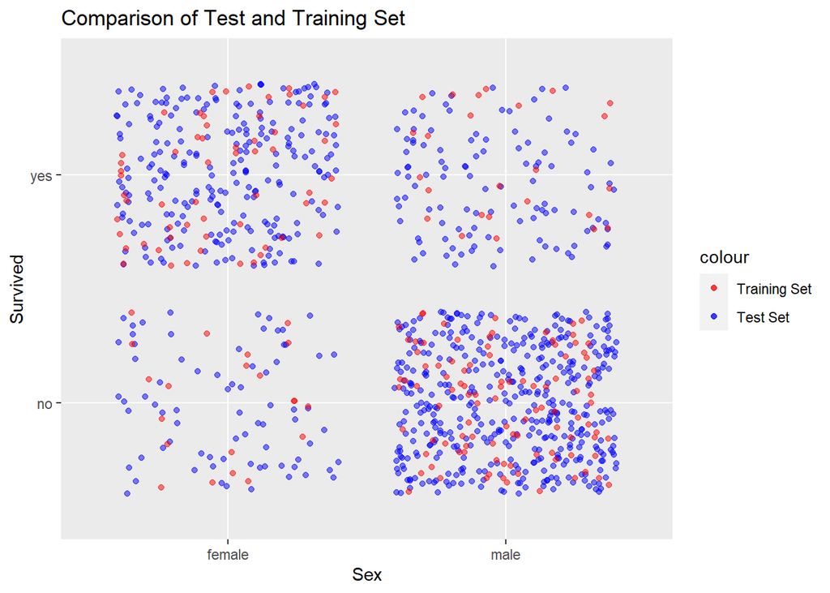

```r
# Using the geom_jitter() function because we have two categorical variables
ggplot() +
  geom_jitter(data = train, aes(x = sex, y = survived, color = "Training Set"), alpha = 0.5) +
  geom_jitter(data = test, aes(x = sex, y = survived, color = "Test Set"), alpha = 0.5) +
  labs(x = "Sex", y = "Survived", title = "Comparison of Test and Training Set") +
  scale_color_manual(values = c("Training Set" = "blue", "Test Set" = "red"),
                     labels = c("Training Set", "Test Set"))
```

## Random Forest Model

```r
set.seed(7)
model <- randomForest(survived~.,data = train)
summary(model)
```

```
##                 Length Class  Mode
## call               3   -none- call
## type               1   -none- character
## predicted        838   factor numeric
## err.rate        1500   -none- numeric
## confusion          6   -none- numeric
## votes           1676   matrix numeric
## oob.times        838   -none- numeric
## classes            2   -none- character
## importance         3   -none- numeric
## importanceSD       0   -none- NULL
## localImportance    0   -none- NULL
## proximity          0   -none- NULL
## ntree              1   -none- numeric
## mtry               1   -none- numeric
## forest            14   -none- list
## y                838   factor numeric
## test               0   -none- NULL
## inbag              0   -none- NULL
## terms              3   terms  call
```

### Visualizing the model

The plot below shows how important each variable was when determining who survived. We can see that the most important variable was sex.

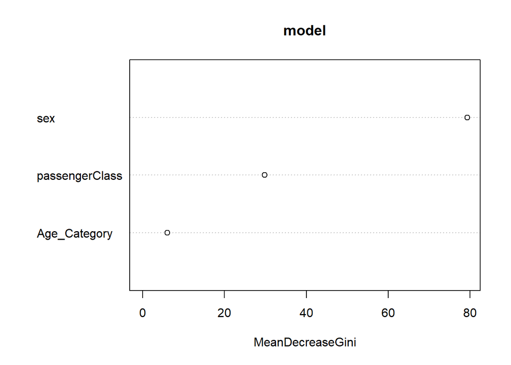

```r
varImpPlot(model)
```

### Testing the model on the test set

As you can see below our model is approximately 81% accurate when compared to the test set.

```r
# Predicting values based on our test set
Prediction <- predict(model,test)
test$predicted <- Prediction

# Making a confusion matrix to test the accuracy
CFM_test <- confusionMatrix(test$predicted, test$survived)
CFM_test
```

```
## Confusion Matrix and Statistics
##
##           Reference
## Prediction  no yes
##        no  116  32
##        yes   7  53
##
##                Accuracy : 0.8125
##                  95% CI : (0.7527, 0.8631)
##     No Information Rate : 0.5913
##     P-Value [Acc > NIR] : 7.915e-12
##
##                   Kappa : 0.5936
##
##  Mcnemar's Test P-Value : 0.0001215
##
##             Sensitivity : 0.9431
##             Specificity : 0.6235
##          Pos Pred Value : 0.7838
##          Neg Pred Value : 0.8833
##              Prevalence : 0.5913
##          Detection Rate : 0.5577
##    Detection Prevalence : 0.7115
##       Balanced Accuracy : 0.7833
##
##        'Positive' Class : no
##
```

### Testing the model on the train set

When we compare our model to the train set it is approximately 78% accurate.

```r
# Predicting values based on our test set
Prediction_train <- predict(model,train)
train$predicted <- Prediction_train

# Making a confusion matrix to test the accuracy
CFM_train <- confusionMatrix(train$predicted, train$survived)
CFM_train
```

```
## Confusion Matrix and Statistics
##
##           Reference
## Prediction  no yes
##        no  466 150
##        yes  30 192
##
##                Accuracy : 0.7852
##                  95% CI : (0.7558, 0.8126)
##     No Information Rate : 0.5919
##     P-Value [Acc > NIR] : < 2.2e-16
##
##                   Kappa : 0.5298
##
##  Mcnemar's Test P-Value : < 2.2e-16
##
##             Sensitivity : 0.9395
##             Specificity : 0.5614
##          Pos Pred Value : 0.7565
##          Neg Pred Value : 0.8649
##              Prevalence : 0.5919
##          Detection Rate : 0.5561
##    Detection Prevalence : 0.7351
##       Balanced Accuracy : 0.7505
##
##        'Positive' Class : no
##
```

# Conclusion

This project gave me a brief introduction to classification models. Overall, the model was around 80% accurate, so I believe this was a success. It is also important to note that the more data you have, the more accurate your model will be because your data can be trained and tested on more observations. The next step would be to deploy this model so that it can be used in different situations. Check out the deploy file for more information.